# R in den Sozialwissenschaften - Teil 2

23 Juni 2017

## Die Pakete `ggplot` und `ggmap`

## Das Paket `ggplot2`

- Entwickelt von Hadley Wickham
- Viele Informationen unter:
- http://ggplot2.org/
- Den Graphiken liegt eine eigene Grammitik zu Grunde

[figure not shown]

## Das Paket `ggplot2` installieren und laden

- Basiseinführung `ggplot2`

```r
install.packages("ggplot2")
```

```r
library(ggplot2)
```

## Der `diamonds` Datensatz

```r
head(diamonds)
```

| carat | cut | color | clarity | depth | table | price | x | y | z |
| --- | --- | --- | --- | --- | --- | --- | --- | --- | --- |
| 0.23 | Ideal | E | SI2 | 61.5 | 55 | 326 | 3.95 | 3.98 | 2.43 |
| 0.21 | Premium | E | SI1 | 59.8 | 61 | 326 | 3.89 | 3.84 | 2.31 |
| 0.23 | Good | E | VS1 | 56.9 | 65 | 327 | 4.05 | 4.07 | 2.31 |
| 0.29 | Premium | I | VS2 | 62.4 | 58 | 334 | 4.20 | 4.23 | 2.63 |
| 0.31 | Good | J | SI2 | 63.3 | 58 | 335 | 4.34 | 4.35 | 2.75 |
| 0.24 | Very Good | J | VVS2 | 62.8 | 57 | 336 | 3.94 | 3.96 | 2.48 |

## Wie nutzt man `qplot`

- Die Funktion `qplot` wird für schnelle Graphiken verwendet (quick plots)
- bei der Funktion `ggplot` kann man alles bis ins Detail kontrollieren

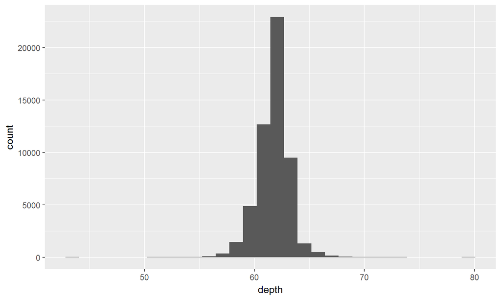

```r
# histogram
qplot(depth, data=diamonds)
```

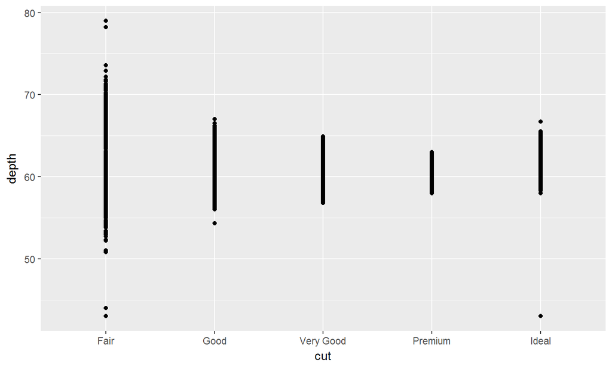

```r
qplot(cut, depth, data=diamonds)
```

## Ein weiteres Balkendiagramm

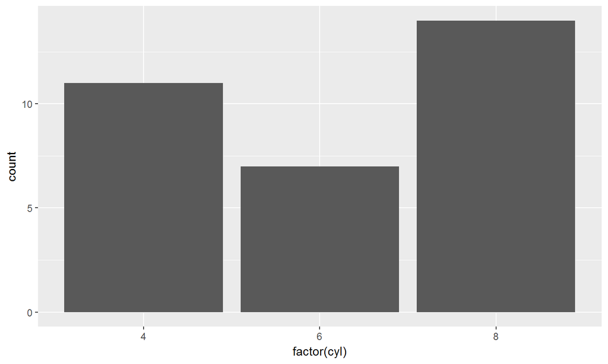

```r
qplot(factor(cyl), data=mtcars,geom="bar")
```

## Boxplot

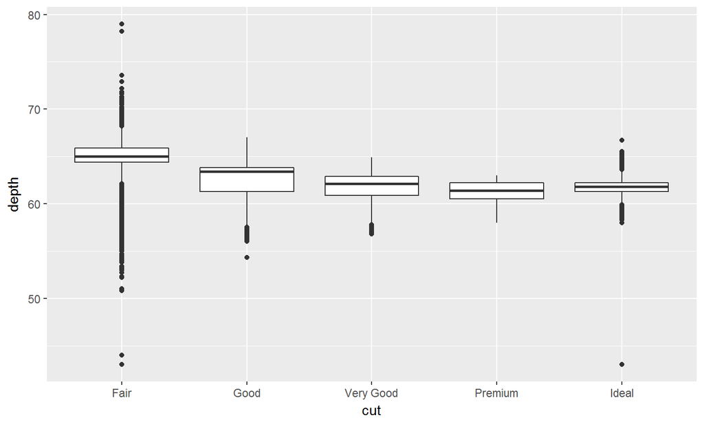

```r
qplot(data=diamonds,x=cut,y=depth,geom="boxplot")
```

## Scatterplot

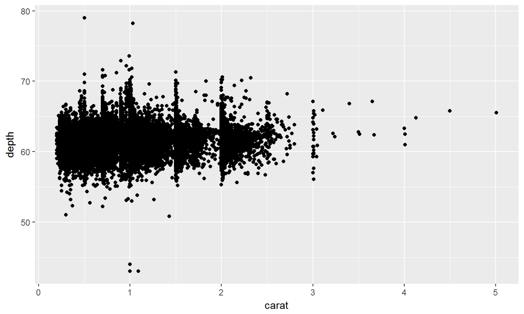

```r
# scatterplot
qplot(carat, depth, data=diamonds)
```

## Farbe hinzu:

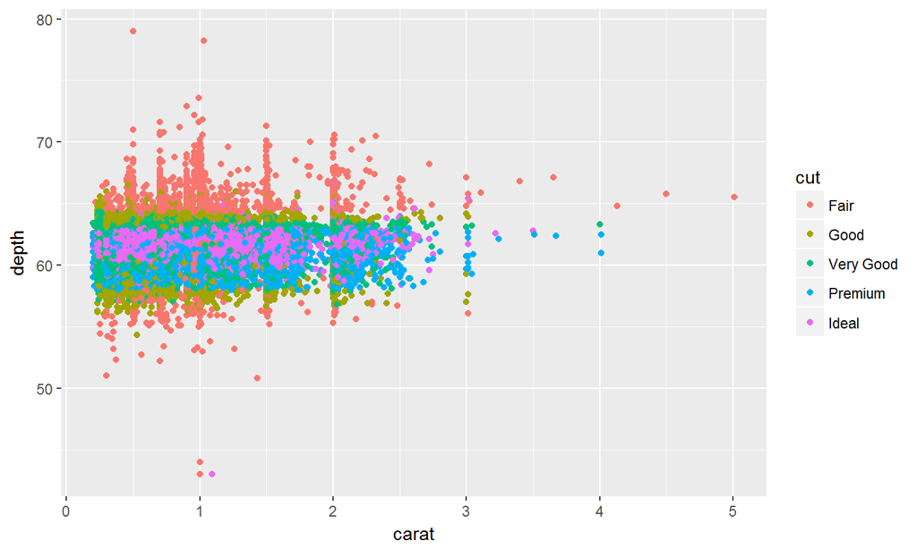

```r
qplot(carat, depth, data=diamonds,color=cut)
```

## Trendlinie hinzufügen

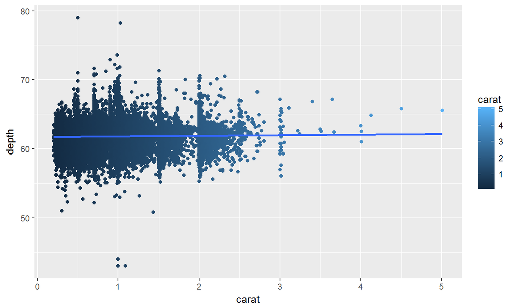

```r
myGG<-qplot(data=diamonds,x=carat,y=depth,color=carat)
myGG + stat_smooth(method="lm")
```

## Graphik drehen

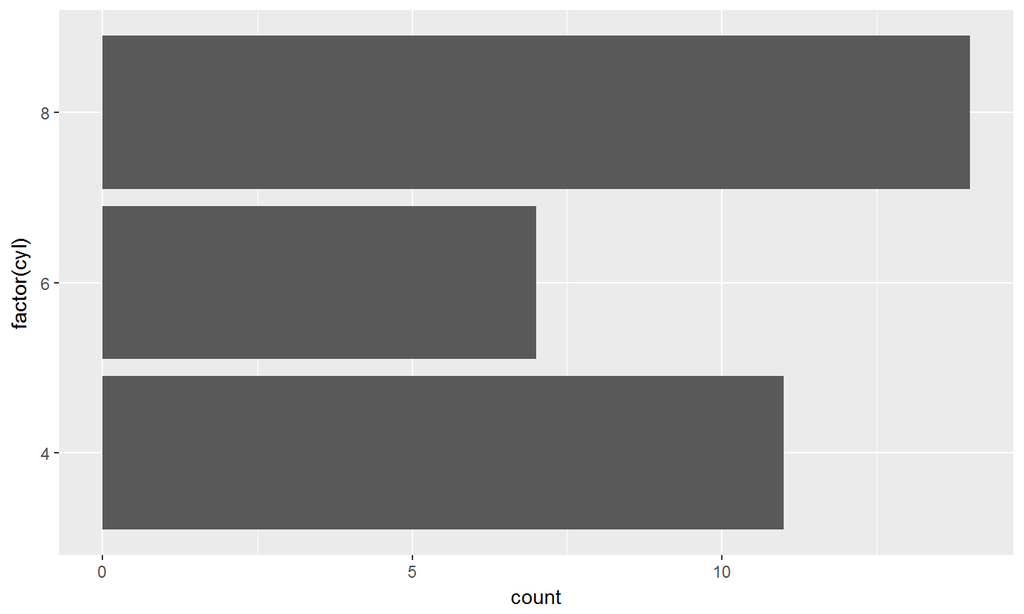

```r
qplot(factor(cyl), data=mtcars, geom="bar") +
coord_flip()
```

## Wie nutzt man ggplot

- die aestetics:

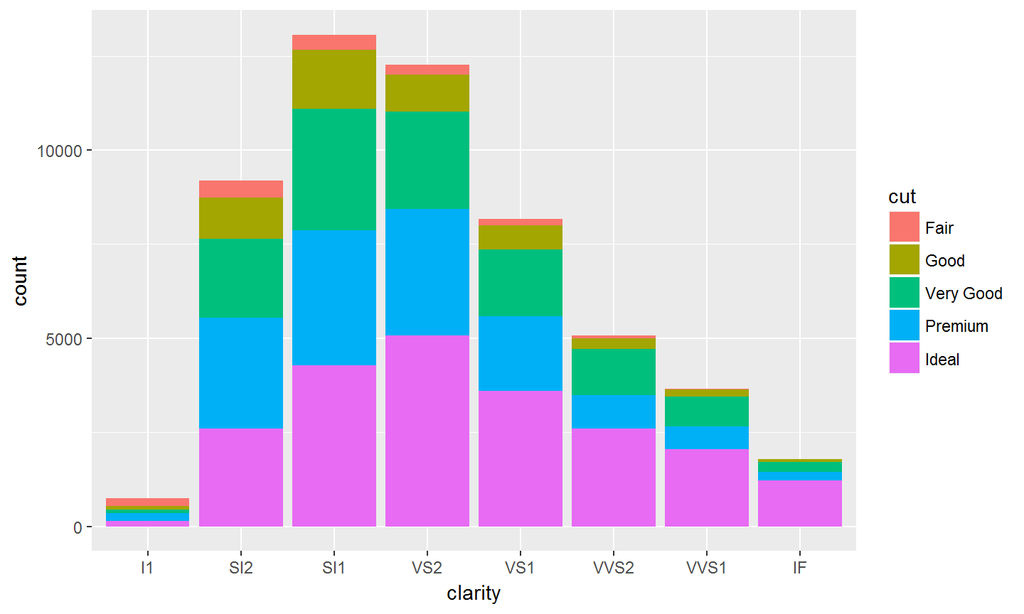

```r
ggplot(diamonds, aes(clarity, fill=cut)) + geom_bar()
```

## Farben selber wählen

Es wird das Paket `RColorBrewer` verwendet um die Farbpalette zu ändern

```r
install.packages("RColorBrewer")
```

```r
library(RColorBrewer)
myColors <- brewer.pal(5,"Accent")
names(myColors) <- levels(diamonds$cut)
colScale <- scale_colour_manual(name = "cut",
                                values = myColors)
```

http://stackoverflow.com/questions/6919025/

## Eine Graphik mit den gewählten Farben

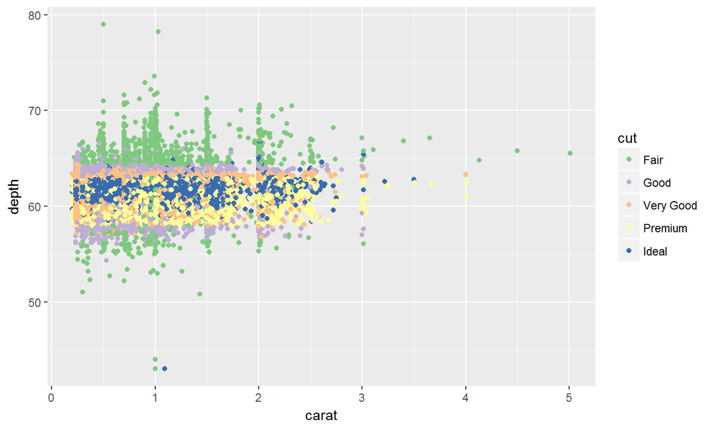

```r
p <- ggplot(diamonds,aes(carat, depth,colour = cut)) +
  geom_point()
p + colScale
```

## Speichern mit ggsave

```r
ggsave("Graphik.jpg")
```

## Links

- [Warum man ggplot2 für einfache Grafiken nutzen sollte](http://www.r-bloggers.com/why-i-use-ggplot2/)

[figure not shown]

- [Einführung in ggplot2](https://opr.princeton.edu/workshops/Downloads/2015Jan_ggplot2Koffman.pdf)

[figure not shown]

- [ggplot2 Basics](http://tutorials.iq.harvard.edu/R/Rgraphics/Rgraphics.html)

- Noam Ross - [Quick Introduction to ggplot2](http://www.noamross.net/blog/2012/10/5/ggplot-introduction.html)
- [Plugin ggplot2](https://www.r-bloggers.com/rcmdrplugin-kmggplot2_0-2-4-is-on-cran/)

## Verschiedene Kartentypen

Arten von räumlichen Daten:

- [Straßenkarten](https://www.nceas.ucsb.edu/~frazier/RSpatialGuides/ggmap/ggmapCheatsheet.pdf)
- [Satelliten Bilder](http://www.mostlymuppet.com/tag/maps/)
- [Physische Daten und Karten](http://gis.stackexchange.com/questions/3083/what-makes-a-map-beautiful/45518#45518)
- [Abstrakte Karten](http://www.designfaves.com/2014/03/abstracted-maps-reveal-cities-personalities)
- …

Das R-paket [ggmap](http://journal.r-project.org/archive/2013-1/kahle-wickham.pdf) wird im folgenden genutzt um verschiedene Kartentypen darzustellen.

Mit qmap kann man eine schnelle Karte erzeugen.

## Straßenkarten

- Straßenkarte werden sehr häufig verwendet.
- Diese Karten zeigen Haupt- und Nebenstraßen (abhängig vom Detail)
- oft sind auch weitere Informationen enthalten. Wie beispielsweise Flughäfen, Städte, Campingplätze oder andere Orte von Interesse
- Beispiel einer Straßenkarte für Mannheim.

## Installieren des Paketes

- Zur Erstellung der Karten brauchen wir das Paket `ggmap`:

```r
devtools::install_github("dkahle/ggmap")
devtools::install_github("hadley/ggplot2")
install.packages("ggmap")
```

## Paket ggmap - Hallo Welt

- Um das Paket zu laden verwenden wir den Befehl `library`

```r
library(ggmap)
```

Und schon kann die erste Karte erstellt werden:

```r
qmap("Mannheim")
```

## Karte für eine Sehenswürdigkeit

```r
BBT <- qmap("Berlin Brandenburger Tor")
BBT
```

## Karte für einen ganzen Staat

```r
qmap("Germany")
```

- Wir brauchen ein anderes *zoom level*

## Ein anderes *zoom level*

- level 3 - Kontinent
- level 10 - Stadt
- level 21 - Gebäude

```r
qmap("Germany", zoom = 6)
```

## Hilfe bekommen wir mit dem Fragezeichen

```r
?qmap
```

Verschiedene Abschnitte in der Hilfe:

- Description
- Usage
- Arguments
- Value
- Author(s)
- See Also
- Examples

## Die Beispiele in der Hilfe

Ausschnitt aus der Hilfe Seite zum Befehl `qmap`:

[figure not shown]

qmap Example

Das Beispiel kann man direkt in die Konsole kopieren:

```r
# qmap("baylor university")
qmap("baylor university", zoom = 14)
# und so weiter
```

## Ein anderes *zoom level*

```r
qmap("Mannheim", zoom = 12)
```

## Näher rankommen

```r
qmap('Mannheim', zoom = 13)
```

## Ganz nah dran

```r
qmap('Mannheim', zoom = 20)
```

## ggmap - maptype satellite

```r
qmap('Mannheim', zoom = 14, maptype="satellite")
```

```r
qmap('Mannheim', zoom = 20, maptype="hybrid")
```

## ggmap - maptype hybrid

```r
qmap("Mannheim", zoom = 14, maptype="hybrid")
```

## Terrain/physical maps

- Aus Physischen Karten kann man Informationen über Berge, Flüsse und Seen ablesen.
- Farben werden oft genutzt um Höhenunterschiede zu visualisieren

## ggmap - terrain map

```r
qmap('Schriesheim', zoom = 14,maptype="terrain")
```

## Abstrahierte Karten ([http://www.designfaves.com](http://www.designfaves.com/2014/03/abstracted-maps-reveal-cities-personalities))

[figure not shown]

New York

- Abstraktion wird genutzt um nur die essentiellen Informationen einer Karte zu zeigen.
- Bsp. U-Bahn Karten - wichtig sind Richtungen und wenig Infos zur Orientierung
- Im folgenden werden Karten vorgestellt, die sich gut als Hintergrundkarten eignen.

## ggmap - maptype watercolor

```r
qmap('Mannheim', zoom = 14,maptype="watercolor",source="stamen")
```

## ggmap - source stamen

```r
qmap('Mannheim', zoom = 14,
 maptype="toner",source="stamen")
```

## ggmap - maptype toner-lite

```r
qmap('Mannheim', zoom = 14,
 maptype="toner-lite",source="stamen")
```

## ggmap - maptype toner-hybrid

```r
qmap('Mannheim', zoom = 14,
 maptype="toner-hybrid",source="stamen")
```

## ggmap - maptype terrain-lines

```r
qmap('Mannheim', zoom = 14,
 maptype="terrain-lines",source="stamen")
```

## Graphiken speichern

[figure not shown]

RstudioExport

## ggmap - ein Objekt erzeugen

- `<-` ist der Zuweisungspfeil um ein Objekt zu erzeugen
- Dieses Vorgehen macht bspw. Sinn, wenn mehrere Karten nebeneinander gebraucht werden.

```r
MA_map <- qmap('Mannheim',
               zoom = 14,
               maptype="toner",
               source="stamen")
```

## Geokodierung

> Geocoding (…) uses a description of a location, most typically a postal address or place name, to find geographic coordinates from spatial reference data …

[Wikipedia - Geocoding](https://github.com/adam-p/markdown-here/wiki/Markdown-Cheatsheet#blockquotes)

```r
library(ggmap)
geocode("Mannheim",source="google")
```

## Latitude und Longitude

[figure not shown]

LatLon

[http://modernsurvivalblog.com](http://modernsurvivalblog.com/survival-skills/basic-map-reading-latitude-longitude/)

## Reverse Geokodierung

> Reverse geocoding is the process of back (reverse) coding of a point location (latitude, longitude) to a readable address or place name. This permits the identification of nearby street addresses, places, and/or areal subdivisions such as neighbourhoods, county, state, or country.

Quelle: [Wikipedia](https://en.wikipedia.org/wiki/Reverse_geocoding)

```r
revgeocode(c(48,8))
```

## Die Distanz zwischen zwei Punkten

```r
mapdist("Q1, 4 Mannheim","B2, 1 Mannheim")
```

```r
mapdist("Q1, 4 Mannheim","B2, 1 Mannheim",mode="walking")
```

## Eine andere Distanz bekommen

```r
mapdist("Q1, 4 Mannheim","B2, 1 Mannheim",mode="bicycling")
```

## Geokodierung - verschiedene Punkte von Interesse

```r
POI1 <- geocode("B2, 1 Mannheim",source="google")
POI2 <- geocode("Hbf Mannheim",source="google")
POI3 <- geocode("Mannheim, Friedrichsplatz",source="google")
ListPOI <-rbind(POI1,POI2,POI3)
POI1;POI2;POI3
```

## Punkte in der Karte

```r
MA_map +
geom_point(aes(x = lon, y = lat),
data = ListPOI)
```

## Punkte in der Karte

```r
MA_map +
geom_point(aes(x = lon, y = lat),col="red",
data = ListPOI)
```

## ggmap - verschiedene Farben

```r
ListPOI$color <- c("A","B","C")
MA_map +
geom_point(aes(x = lon, y = lat,col=color),
data = ListPOI)
```

## ggmap - größere Punkte

```r
ListPOI$size <- c(10,20,30)
MA_map +
geom_point(aes(x = lon, y = lat,col=color,size=size),
data = ListPOI)
```

## Eine Route von Google maps bekommen

```r
from <- "Mannheim Hbf"
to <- "Mannheim B2 , 1"
route_df <- route(from, to, structure = "route")
```

[Mehr Information](http://rpackages.ianhowson.com/cran/ggmap/man/route.html)

http://rpackages.ianhowson.com/cran/ggmap/man/route.html

## Eine Karte mit dieser Information zeichnen

```r
qmap("Mannheim Hbf", zoom = 14) +
  geom_path(
    aes(x = lon, y = lat),  colour = "red", size = 1.5,
    data = route_df, lineend = "round"
  )
```

Wie fügt man Punkte hinzu

- Nutzung von [geom_point](http://zevross.com/blog/2014/07/16/mapping-in-r-using-the-ggplot2-package/)
- Question on [stackoverflow](http://stackoverflow.com/questions/15069963/getting-a-map-with-points-using-ggmap-and-ggplot2)

http://i.stack.imgur.com

[figure not shown]

## Cheatsheet

- Cheatsheet zu [data visualisation](https://www.rstudio.com/wp-content/uploads/2015/04/ggplot2-cheatsheet.pdf)

https://www.rstudio.com/

[figure not shown]

Cheatsheet

## Resourcen und Literatur

- [Artikel von David Kahle und Hadley Wickham](http://journal.r-project.org/archive/2013-1/kahle-wickham.pdf) zur Nutzung von `ggmap`.
- [Schnell eine Karte bekommen](http://rpackages.ianhowson.com/cran/ggmap/man/get_map.html)
- [Karten machen mit R](http://www.kevjohnson.org/making-maps-in-r-part-2/)
- [Problem mit der Installation von ggmap](http://stackoverflow.com/questions/40642850/ggmap-error-geomrasterann-was-built-with-an-incompatible-version-of-ggproto)

## Take Home Message

Was klar sein sollte:

- Wie man eine schnelle Karte erzeugt
- Wie man geokodiert
- Wie man eine Distanz berechnet

## Die lineare Regression

## Die lineare Regression

Maindonald - [Data Analysis](https://cran.r-project.org/doc/contrib/usingR.pdf)

- Einführung in R
- Datenanalyse
- Statistische Modelle
- Inferenzkonzepte
- Regression mit einem Prädiktor
- Multiple lineare Regression
- Ausweitung des linearen Modells
- …

## Lineare Regression in R - Beispieldatensatz

John H. Maindonald and W. John Braun

DAAG - [Data Analysis and Graphics Data and Functions](http://cran.ms.unimelb.edu.au/web/packages/DAAG/DAAG.pdf)

```r
install.packages("DAAG")
```

```r
library("DAAG")
data(roller)
```

help on roller data:

```r
?roller
```

## Das lineare Regressionsmodell in R

Schätzen eines Regressionsmodells:

```r
roller.lm <- lm(depression ~ weight, data = roller)
```

So bekommt man die Schätzwerte:

```r
summary(roller.lm)
```

```
##
## Call:
## lm(formula = depression ~ weight, data = roller)
##
## Residuals:
##    Min     1Q Median     3Q    Max
## -8.180 -5.580 -1.346  5.920  8.020
##
## Coefficients:
##             Estimate Std. Error t value Pr(>|t|)
## (Intercept)  -2.0871     4.7543  -0.439  0.67227
## weight        2.6667     0.7002   3.808  0.00518 **
## ---
## Signif. codes:  0 '***' 0.001 '**' 0.01 '*' 0.05 '.' 0.1 ' ' 1
##
## Residual standard error: 6.735 on 8 degrees of freedom
## Multiple R-squared:  0.6445, Adjusted R-squared:  0.6001
## F-statistic:  14.5 on 1 and 8 DF,  p-value: 0.005175
```

Falls das Modell ohne Intercept gesch?tzt werden soll:

```r
lm(depression ~ -1 + weight, data = roller)
```

```
##
## Call:
## lm(formula = depression ~ -1 + weight, data = roller)
##
## Coefficients:
## weight
##  2.392
```

## Summary des Modells

```r
summary(roller.lm)
```

```
##
## Call:
## lm(formula = depression ~ weight, data = roller)
##
## Residuals:
##    Min     1Q Median     3Q    Max
## -8.180 -5.580 -1.346  5.920  8.020
##
## Coefficients:
##             Estimate Std. Error t value Pr(>|t|)
## (Intercept)  -2.0871     4.7543  -0.439  0.67227
## weight        2.6667     0.7002   3.808  0.00518 **
## ---
## Signif. codes:  0 '***' 0.001 '**' 0.01 '*' 0.05 '.' 0.1 ' ' 1
##
## Residual standard error: 6.735 on 8 degrees of freedom
## Multiple R-squared:  0.6445, Adjusted R-squared:  0.6001
## F-statistic:  14.5 on 1 and 8 DF,  p-value: 0.005175
```

## R arbeitet mit Objekten

- `roller.lm` ist nun ein spezielles Regressions-Objekt
- Auf dieses Objekt können nun verschiedene Funktionen angewendet werden

```r
predict(roller.lm) # Vorhersage
```

```
##         1         2         3         4         5         6         7
##  2.979669  6.179765  6.713114 10.713233 12.046606 14.180002 14.980026
##         8         9        10
## 18.180121 24.046962 30.980502
```

```r
resid(roller.lm) # Residuen
```

```
##          1          2          3          4          5          6
## -0.9796695 -5.1797646 -1.7131138 -5.7132327  7.9533944  5.8199976
##          7          8          9         10
##  8.0199738 -8.1801213  5.9530377 -5.9805017
```

## Residuenplot

- Sind Annahmen des linearen Regressionsmodells verletzt?
- Dies ist der Fall, wenn ein Muster abweichend von einer Linie zu erkennen ist.
- Hier ist der Datensatz sehr klein

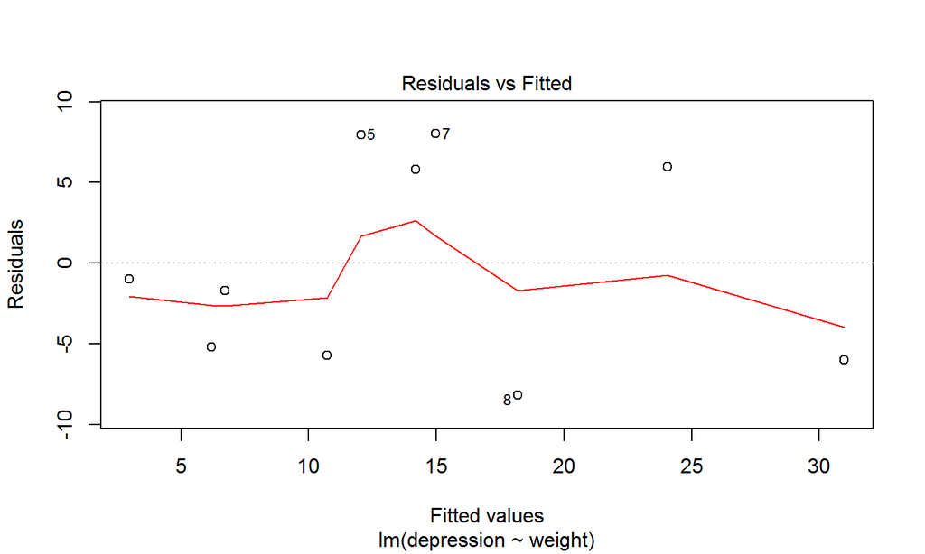

```r
plot(roller.lm,1)
```

## Residuenplot

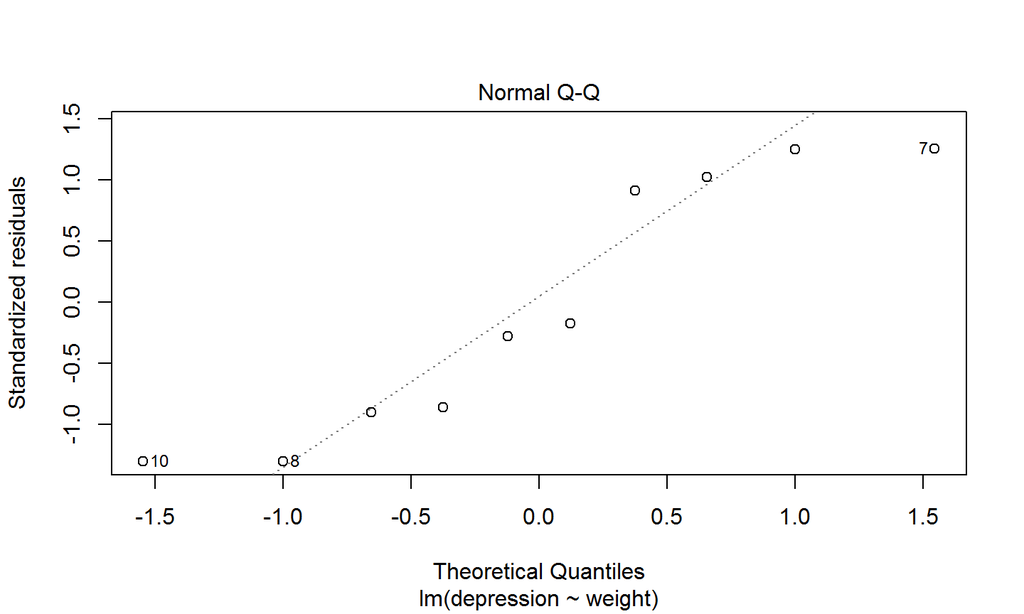

```r
plot(roller.lm,2)
```

- Wenn die Residuen normalverteilt sind sollten sie auf einer Linie liegen.

## Regressionsdiagnostik mit Basis-R

Ein einfaches Modell

```r
N <- 5
x1 <- rnorm(N)
y <- runif(N)
```

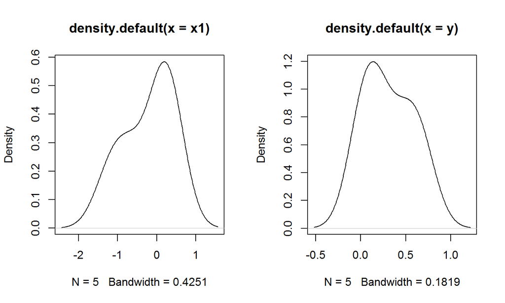

```r
par(mfrow=c(1,2))
plot(density(x1))
plot(density(y))
```

## Modellvorhersage machen

```r
mod1 <- lm(y~x1)
pre <- predict(mod1)
y
```

```
## [1] 0.08132782 0.25203137 0.02478898 0.67305217 0.51547696
```

```r
pre
```

```
##          1          2          3          4          5
## 0.41571144 0.18834357 0.03351329 0.45645742 0.45265156
```

## Regressionsdiagnostik mit Basis-R

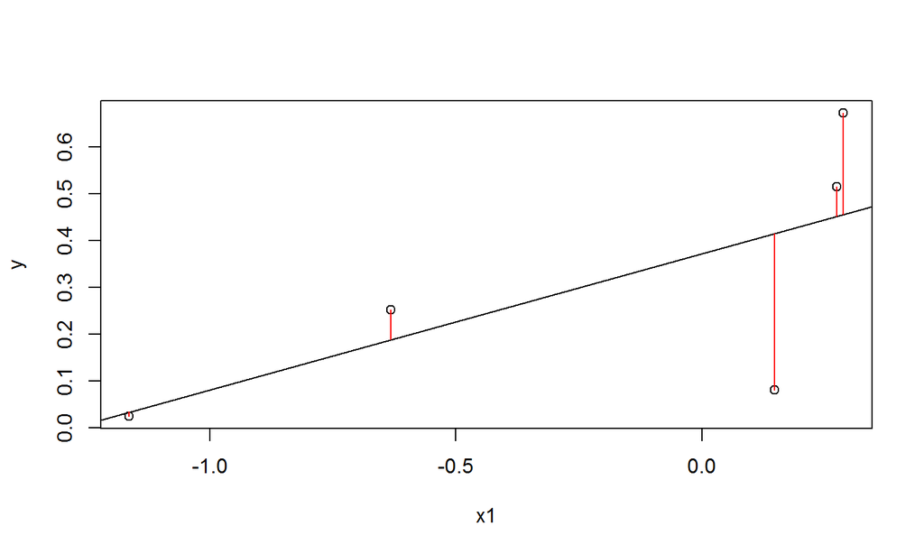

```r
plot(x1,y)
abline(mod1)
segments(x1, y, x1, pre, col="red")
```

## Beispieldaten Luftqualität

```r
library(datasets)
?airquality
```

[figure not shown]

## Das `visreg`-Paket

Ein Modell wird auf dem airquality Datensatz geschätzt

```r
install.packages("visreg")
```

```r
library(visreg)
fit <- lm(Ozone ~ Solar.R + Wind + Temp, data = airquality)
summary(fit)
```

```
##
## Call:
## lm(formula = Ozone ~ Solar.R + Wind + Temp, data = airquality)
##
## Residuals:
##     Min      1Q  Median      3Q     Max
## -40.485 -14.219  -3.551  10.097  95.619
##
## Coefficients:
##              Estimate Std. Error t value Pr(>|t|)
## (Intercept) -64.34208   23.05472  -2.791  0.00623 **
## Solar.R       0.05982    0.02319   2.580  0.01124 *
## Wind         -3.33359    0.65441  -5.094 1.52e-06 ***
## Temp          1.65209    0.25353   6.516 2.42e-09 ***
## ---
## Signif. codes:  0 '***' 0.001 '**' 0.01 '*' 0.05 '.' 0.1 ' ' 1
##
## Residual standard error: 21.18 on 107 degrees of freedom
##   (42 observations deleted due to missingness)
## Multiple R-squared:  0.6059, Adjusted R-squared:  0.5948
## F-statistic: 54.83 on 3 and 107 DF,  p-value: < 2.2e-16
```

## Visualisierung

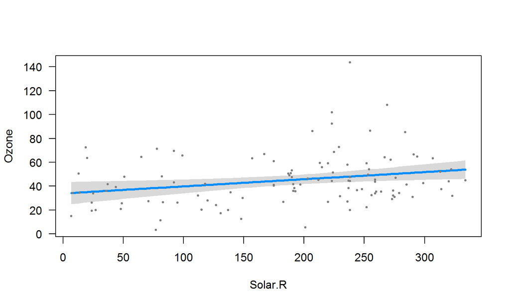

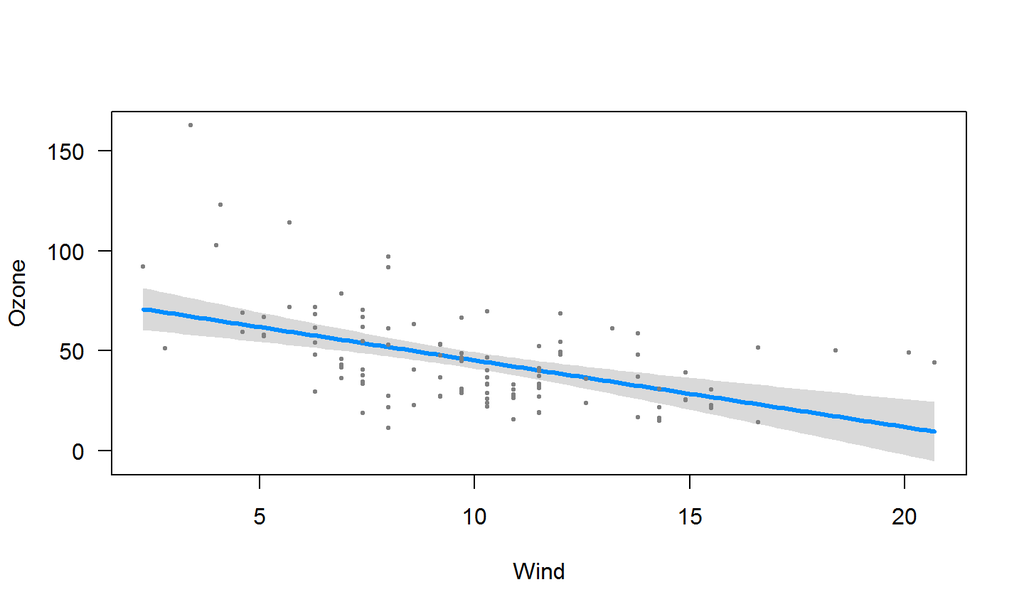

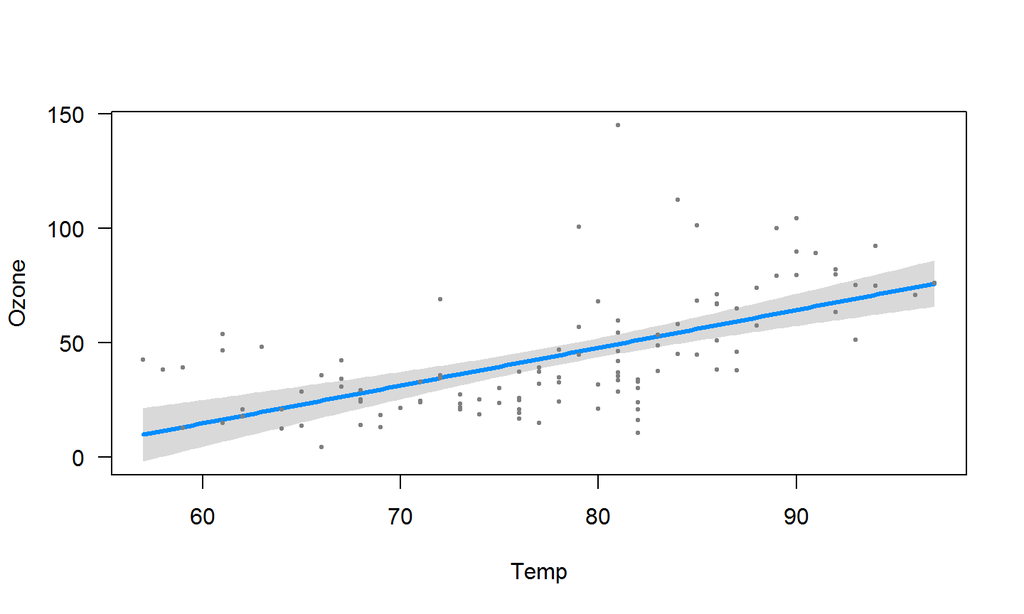

```r
visreg(fit)
```

## [Und dann mit `visreg` visualisiert.](http://myweb.uiowa.edu/pbreheny/publications/visreg.pdf)

- Zweites Argument - Spezifikation erklärende Variable für Visualisierung

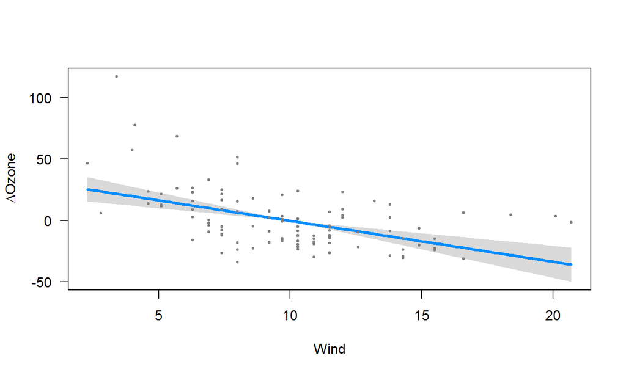

```r
visreg(fit, "Wind", type = "contrast")
```

## Visualisierung mit dem Paket `visreg`

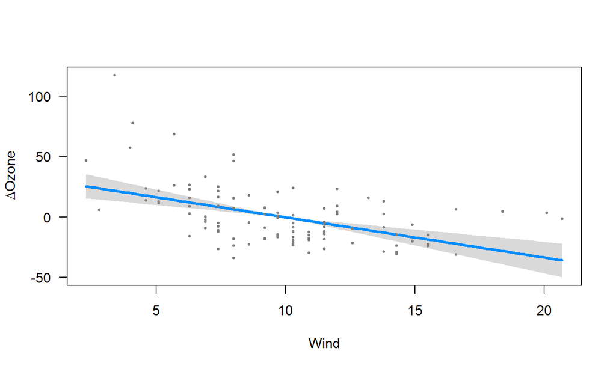

```r
visreg(fit, "Wind", type = "contrast")
```

## Das `visreg`-Paket

- Das Default-Argument für type ist conditional.

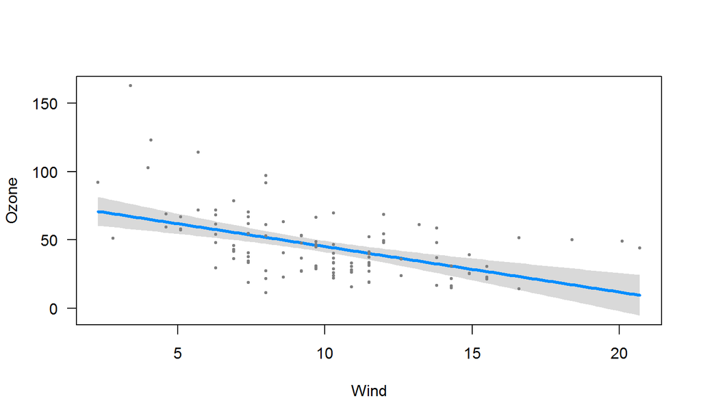

```r
visreg(fit, "Wind", type = "conditional")
```

## Regression mit Faktoren

Mit `visreg` können die Effekte bei Faktoren visualisiert werden.

```r
airquality$Heat <- cut(airquality$Temp, 3,
    labels=c("Cool", "Mild", "Hot"))
fit.heat <- lm(Ozone ~ Solar.R + Wind + Heat,
    data = airquality)
summary(fit.heat)
```

```
##
## Call:
## lm(formula = Ozone ~ Solar.R + Wind + Heat, data = airquality)
##
## Residuals:
##     Min      1Q  Median      3Q     Max
## -33.473 -12.794  -2.686   8.461 107.035
##
## Coefficients:
##             Estimate Std. Error t value Pr(>|t|)
## (Intercept) 48.27682    8.83072   5.467 3.07e-07 ***
## Solar.R      0.06524    0.02145   3.042  0.00296 **
## Wind        -3.49803    0.59042  -5.925 3.94e-08 ***
## HeatMild     9.05367    4.88257   1.854  0.06648 .
## HeatHot     43.13970    5.98618   7.207 8.79e-11 ***
## ---
## Signif. codes:  0 '***' 0.001 '**' 0.01 '*' 0.05 '.' 0.1 ' ' 1
##
## Residual standard error: 19.9 on 106 degrees of freedom
##   (42 observations deleted due to missingness)
## Multiple R-squared:  0.6554, Adjusted R-squared:  0.6424
## F-statistic:  50.4 on 4 and 106 DF,  p-value: < 2.2e-16
```

## Effekte von Faktoren

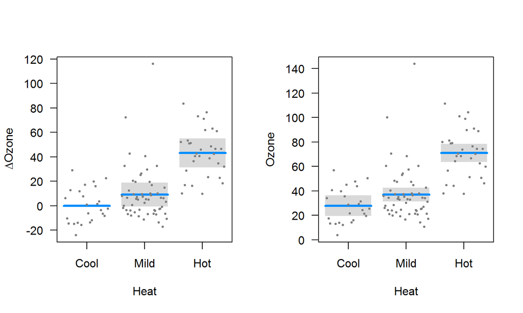

```r
par(mfrow=c(1,2))
visreg(fit.heat, "Heat", type = "contrast")
visreg(fit.heat, "Heat", type = "conditional")
```

## Das Paket visreg - Interaktionen

```r
airquality$Heat <- cut(airquality$Temp, 3,
labels=c("Cool", "Mild", "Hot"))
fit <- lm(Ozone ~ Solar.R + Wind * Heat, data = airquality)
summary(fit)
```

```
##
## Call:
## lm(formula = Ozone ~ Solar.R + Wind * Heat, data = airquality)
##
## Residuals:
##     Min      1Q  Median      3Q     Max
## -34.472 -11.640  -1.919   7.403 102.428
##
## Coefficients:
##               Estimate Std. Error t value Pr(>|t|)
## (Intercept)    4.48042   17.38219   0.258 0.797102
## Solar.R        0.07634    0.02137   3.572 0.000538 ***
## Wind           0.05854    1.34860   0.043 0.965458
## HeatMild      56.72928   18.53110   3.061 0.002805 **
## HeatHot       94.68619   18.61619   5.086 1.63e-06 ***
## Wind:HeatMild -4.11933    1.57108  -2.622 0.010054 *
## Wind:HeatHot  -4.88125    1.74358  -2.800 0.006101 **
## ---
## Signif. codes:  0 '***' 0.001 '**' 0.01 '*' 0.05 '.' 0.1 ' ' 1
##
## Residual standard error: 19.28 on 104 degrees of freedom
##   (42 observations deleted due to missingness)
## Multiple R-squared:  0.6825, Adjusted R-squared:  0.6642
## F-statistic: 37.26 on 6 and 104 DF,  p-value: < 2.2e-16
```

## Steuern der Graphikausgabe mittels `layout`

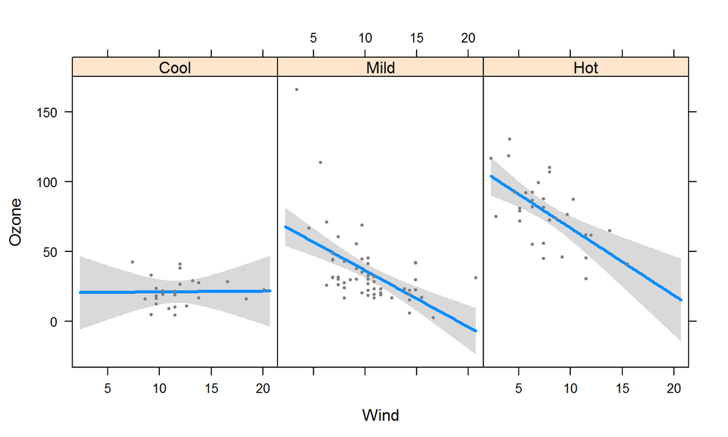

```r
visreg(fit, "Wind", by = "Heat",layout=c(3,1))
```

## Das Paket `visreg` - Interaktionen overlay

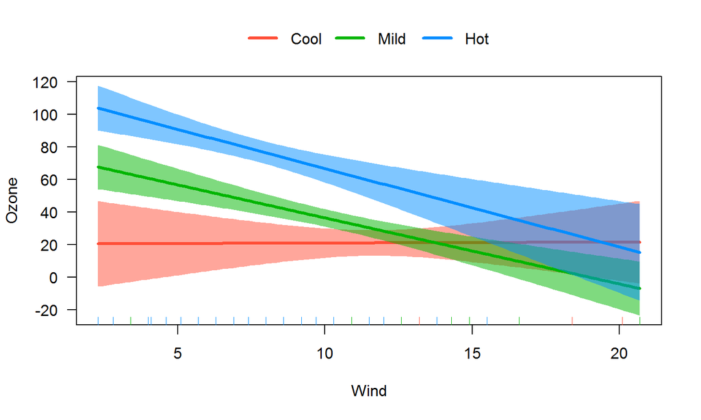

```r
fit <- lm(Ozone ~ Solar.R + Wind * Heat, data = airquality)
visreg(fit, "Wind", by="Heat", overlay=TRUE, partial=FALSE)
```

## Das Paket `visreg` - `visreg2d`

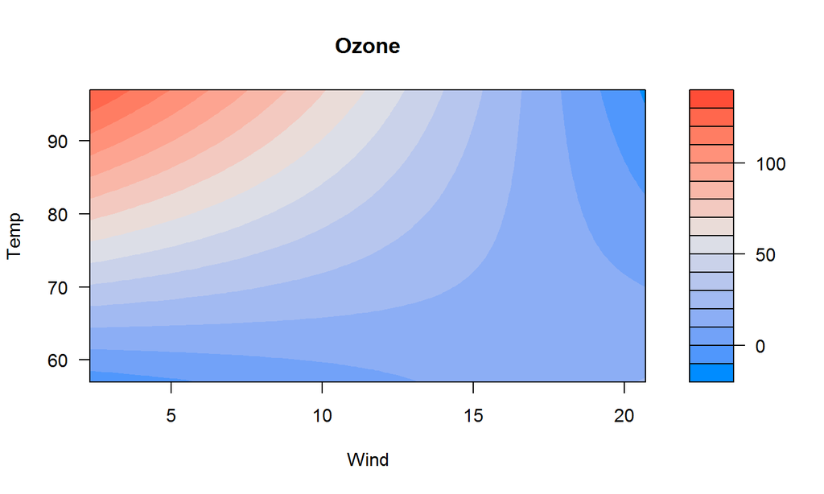

```r
fit2 <- lm(Ozone ~ Solar.R + Wind * Temp, data = airquality)
visreg2d(fit2, "Wind", "Temp", plot.type = "image")
```

## Das Paket visreg - surface

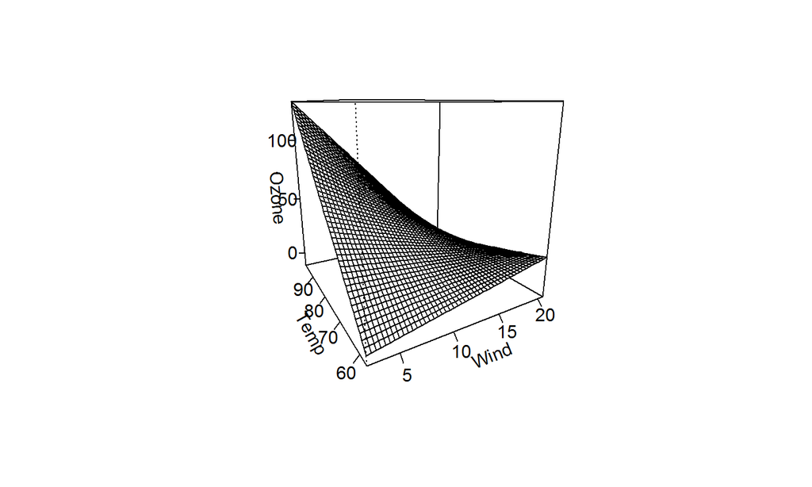

```r
visreg2d(fit2, "Wind", "Temp", plot.type = "persp")
```

## Linkliste - lineare Regression

- Regression - [r-bloggers](http://www.r-bloggers.com/r-tutorial-series-simple-linear-regression/)
- Das Komplette Buch von [Faraway](http://cran.r-project.org/doc/contrib/Faraway-PRA.pdf)- sehr intuitiv geschrieben.
- Gute Einführung auf [Quick-R](http://www.statmethods.net/stats/regression.html)
- [Multiple Regression](https://www.r-bloggers.com/multiple-regression-part-1/)
- Basis Regression - [How to go about interpreting regression cofficients](https://www.r-bloggers.com/how-to-go-about-interpreting-regression-cofficients/)

## Die logistische Regression

## Agresti - [Categorical Data Analysis (2002)](https://mathdept.iut.ac.ir/sites/mathdept.iut.ac.ir/files/AGRESTI.PDF)

[figure not shown]

- Sehr intiutiv geschriebenes Buch
- Sehr ausführliches begleitendes Skript von [Thompson](http://statweb.stanford.edu/~owen/courses/306a/Splusdiscrete2.pdf)
- Das Skript eignet sich um die kategoriale Datenanalyse nachzuvollziehen

## Faraway Bücher zu Regression in R

[figure not shown]

- Logistische Regressionen gut erklärt
- Beispiele mit R-code
  - Faraway - Extending the linear model with r
  - Faraway - [Practical Regression and Anova using R](https://cran.r-project.org/doc/contrib/Faraway-PRA.pdf)

## Binäre AVs mit `glm`

- Die [logistische Regression](http://data.princeton.edu/R/glms.html) gehört zur Klasse der generalisierten linearen Modelle (GLM)
- Die Funktion zur Schätzung eines Modells dieser Klasse in heißt `glm()`
- `glm()` muss 1. ein Formel-Objekt mitgegeben werden und 2. die Klasse (binomial, gaussian, Gamma) samt link-Funktion (logit, probit, cauchit, log, cloglog)

## Beispieldaten für die logistische Regression

```r
install.packages("HSAUR")
```

```r
library("HSAUR")
data("plasma", package = "HSAUR")
```

## Logistische Regression mit R

- [Kategoriale Daten:](http://homepage.univie.ac.at/herbert.nagel/KategorialeDaten.pdf)

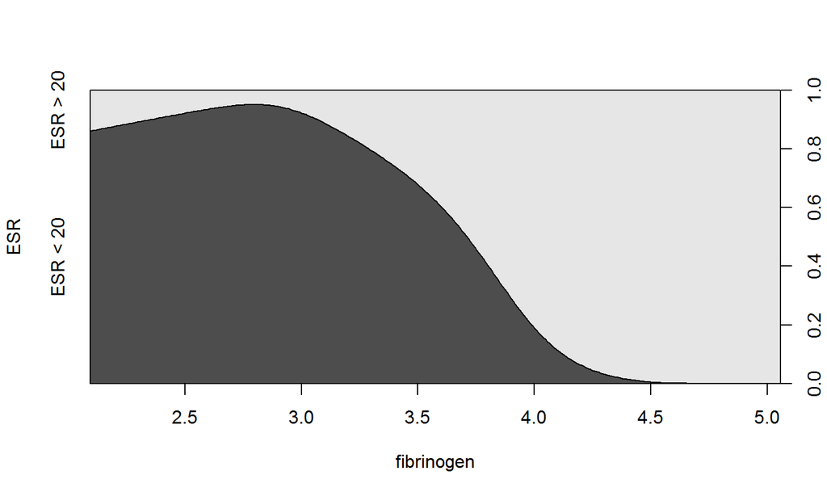

```r
cdplot(ESR ~ fibrinogen, data = plasma)
```

## [Logistische Regression](http://ww2.coastal.edu/kingw/statistics/R-tutorials/logistic.html) mit R

```r
plasma_glm_1 <- glm(ESR ~ fibrinogen, data = plasma,
                    family = binomial())
```

## Weitere Beispieldaten

```r
install.packages("faraway")
```

```r
library("faraway")
```

```r
data(orings)
```

| temp | damage |
| --- | --- |
| 53 | 5 |
| 57 | 1 |
| 58 | 1 |

## Generalisierte Regression mit R - weitere Funktionen

- Logistisches Modell mit Probit-Link:

```r
probitmod <- glm(cbind(damage,6-damage) ~ temp,
    family=binomial(link=probit), orings)
```

- Regression mit Zähldaten:

```r
modp <- glm(Species ~ .,family=poisson,gala)
```

- Proportional odds logistic regression im Paket `MASS`:

```r
library("MASS")
house.plr<-polr(Sat~Infl,weights=Freq,data=housing)
```

## Linkliste - logistische Regression

- Einführung in [logistische Regression](http://ww2.coastal.edu/kingw/statistics/R-tutorials/logistic.html)

[figure not shown]

- [Code zum Buch von Faraway](http://www.maths.bath.ac.uk/~jjf23/ELM/scripts/binary.R)

[figure not shown]

## Mehrebenenmodelle

## Wie sehen die Daten aus?

- Beispiel Mehrebenenstruktur der Daten

[figure not shown]

## [Andres Gutierrez - Multilevel Modeling of Educational Data using R](https://www.r-bloggers.com/multilevel-modeling-of-educational-data-using-r-part-1/)

- Lineare Modelle erkennen den Cluster-Effekt aufgrund der Intraklassen Korrelation nicht

[figure not shown]

- [Original Blog](http://hagutierrezro.blogspot.de/2016/10/multilevel-modeling-of-educational-data.html)

## Beispiel Mehrebenenmodelle

Untersuchungsgegenstand

- Es sollen die Kenntnisse (Fähigkeiten) von Grundschülern in Mathematik gemessen werden.
- Dazu werden in einem Schulbezirk zunächst Schulen ausgewählt und anschließend Klassen.
- Innerhalb der Klassen soll schließlich jeweils eine Stichprobe gezogen und diese getestet werden.
- Geht man zunächst von einer zufälligen Auswahl von Klassen aus, dann ist die Level-1-Variation durch die Schüler und die Level-2-Variation durch die Klassen bestimmt.

## Fragen hierzu

- Wie wäre die Auswahl der Schulen zu berücksichtigen?
- Wie kann zusätzlich eine Unterscheidung nach privaten und staatlichen Schulen in die Modellierung eingebracht werden?

## Beispiel in Goldstein (2010), Kapitel 1.2

Evaluierung der Effektivität von Schulen

Mehrebenen-Modelle:

- Schüler
- Klassenverbände
- Schulamtsbezirke oder Bundesländer

Unterscheidung

- Modelle mit vielen Parametern, die wiederum modelliert werden können
- Regressionen mit Koeffizienten, die zwischen Gruppen variieren können

## Bibliotheken

```r
install.packages("lme4")
install.packages("sjPlot")
```

```r
library(ggplot2)
library(gridExtra)
library(lme4)
library(sjPlot)
library(dplyr)
```

## Beispieldaten

```r
mlexdat <- read.csv(
"https://github.com/Japhilko/RSocialScience/
raw/master/data/mlexdat.csv")
```

| X | SES | Score | ID |
| --- | --- | --- | --- |
| 1 | 18.62733 | -55.120574 | A |
| 2 | 33.64915 | -92.375273 | A |
| 3 | 22.26931 | -48.783447 | A |
| 4 | 36.49052 | 38.099329 | A |
| 5 | 38.21402 | 339.701754 | A |
| 6 | 11.36669 | 2.286978 | A |

## [Formalistisch](http://kesdev.com/you-got-latex-in-my-markdown/)

- Bei der Analyse von Daten mit diesen hierarchischen Strukturen, sollte man immer zunächst ein Null-Modell anpassen
- Somit kann man die Variation erfassen, die auf die Schulen zurückzuführen ist:
- Das passende Modell sieht folgendermaßen aus:

Die Gesamtvariation wird in zwei Teile zerlegt:

- Variation zwischen Schülern (innerhalb der Schulen) und
- zwischen den Schulen (zwischen den Schulen).

## Der R-code für dieses Nullmodell

- das einfachste Multilevel Modell
- nach dem vertikalen Strich wird die Gruppen Variable spezifiziert
- die Default Schätzmethode ist restricted maximum likelihood (REML)
- Man kann aber auch maximum likelihood Schätzung spezifizieren (ML)

```r
HLM0 <- lmer(Score ~ (1 | ID), data = mlexdat)
```

## Nullmodell Ergebnis

```r
coef(HLM0)
```

```
## $ID
##   (Intercept)
## A     45.7893
## B    430.7218
## C   1182.1760
## D   2145.2329
## E   3489.1408
##
## attr(,"class")
## [1] "coef.mer"
```

```r
summary(HLM0)
```

```
## Linear mixed model fit by REML ['lmerMod']
## Formula: Score ~ (1 | ID)
##    Data: mlexdat
##
## REML criterion at convergence: 7130.6
##
## Scaled residuals:
##      Min       1Q   Median       3Q      Max
## -2.74559 -0.69317 -0.00757  0.68337  2.96511
##
## Random effects:
##  Groups   Name        Variance Std.Dev.
##  ID       (Intercept) 1931758  1389.9
##  Residual               87346   295.5
## Number of obs: 500, groups:  ID, 5
##
## Fixed effects:
##             Estimate Std. Error t value
## (Intercept)   1458.6      621.7   2.346
```

## Interpratation des Nullmodells

- 96 Prozent Variation zwischen den Schulen
- 4 Prozent Variation innerhalb der Schulen

```r
100 * 87346 / (87346 + 1931757)
```

```
## [1] 4.32598
```

- Die Schätzung der zufälligen Effekte zeigt, dass die Variation zwischen den Schulen (Intraklassen Korrelation) fast 96 Prozent beträgt
- Während der Anteil der Variation zwischen den Studierenden nur etwas mehr als 4 Prozent ausmacht.
- Das Null-Modell behauptet also , dass Leistungsträger zu bestimmten Schulen gehen und Studierende mit geringerem Leistungsniveau nicht diese Schulen besuchen.
- Mit anderen Worten, die Schule bestimmt das Testergebnis.

## Ein weiteres Modell

- Das Null Modell schließt keine erklärenden Variablen ein.
- Allerdings könnte der sozioökonomischen Status (SES) der Schüler auch eine Rolle spielen.
- Die folgenden Ausdrücke geben ein verfeinertes Modell mit zufälligen Achsenabschnitten und Steigung für jede der Schulen:

\[y_{ij} = \alpha_{j} + \beta_{j} * SES_{ij} + \varepsilon_{ij}\]

\[\alpha_{j} = \alpha_0 + u_{j}\] \[\beta{j} = \beta_0 + v_{j}\]

## Rcode für dieses Modell

```r
HLM1 <- lmer(Score ~ SES + (SES | ID), data = mlexdat)
coef(HLM1)
```

```
## $ID
##   (Intercept)        SES
## A    36.46401  0.3798185
## B    37.21549  9.7596237
## C    38.10719 20.8897245
## D    38.85566 30.2320132
## E    39.70159 40.7907386
##
## attr(,"class")
## [1] "coef.mer"
```

```r
summary(HLM1)
```

```
## Linear mixed model fit by REML ['lmerMod']
## Formula: Score ~ SES + (SES | ID)
##    Data: mlexdat
##
## REML criterion at convergence: 6742.1
##
## Scaled residuals:
##      Min       1Q   Median       3Q      Max
## -2.83274 -0.64740  0.02662  0.69063  2.67309
##
## Random effects:
##  Groups   Name        Variance Std.Dev. Corr
##  ID       (Intercept)     1.65   1.285
##           SES           257.09  16.034  1.00
##  Residual             40400.24 200.998
## Number of obs: 500, groups:  ID, 5
##
## Fixed effects:
##             Estimate Std. Error t value
## (Intercept)   38.069     45.863   0.830
## SES           20.410      7.236   2.821
##
## Correlation of Fixed Effects:
##     (Intr)
## SES -0.119
```

```r
# 1% - BS variance
# 99% - WS variance
100 * 40400.24 / (40400.24 + 257.09 + 1.65)
```

```
## [1] 99.36363
```

```r
# Percentage of variation explained by SES between schools
1 - ((257.09 + 1.65) / 1931757)
```

```
## [1] 0.9998661
```

```r
# Percentage of variation explained by SES within schools
1 - (40400.24 / 87346)
```

```
## [1] 0.5374689
```

- die Variable `SES` erklärt 99 Prozent der Unterschiede zwischen den Schulen
- diese Variable `SES` erklärt 53 Prozent der Abweichungen innerhalb der Schulen.

## Was heißt das? - Schulsegregation

- wohlhabende Studenten gehören zu reichen Schulen
- arme Studenten gehören zu armen Schulen.
- Die Leistung der wohlhabenden Studenten ist höher als die der armen Studenten.

## Ein weiteres Beispiel zur [Spezifikation von Multilevel Modellen](http://www.rensenieuwenhuis.nl/r-sessions-16-multilevel-model-specification-lme4/)

- benötigte Bibliotheken:

```r
library(lme4)
library(mlmRev)
```

## Der Datensatz

```r
data(Exam)
# names(Exam)
```

| school | normexam | schgend | schavg | vr | intake | standLRT | sex | type | student |
| --- | --- | --- | --- | --- | --- | --- | --- | --- | --- |
| 1 | 0.2613242 | mixed | 0.1661752 | mid 50% | bottom 25% | 0.6190592 | F | Mxd | 143 |
| 1 | 0.1340672 | mixed | 0.1661752 | mid 50% | mid 50% | 0.2058022 | F | Mxd | 145 |
| 1 | -1.7238820 | mixed | 0.1661752 | mid 50% | top 25% | -1.3645760 | M | Mxd | 142 |
| 1 | 0.9675862 | mixed | 0.1661752 | mid 50% | mid 50% | 0.2058022 | F | Mxd | 141 |
| 1 | 0.5443412 | mixed | 0.1661752 | mid 50% | mid 50% | 0.3711052 | F | Mxd | 138 |
| 1 | 1.7348992 | mixed | 0.1661752 | mid 50% | bottom 25% | 2.1894372 | M | Mxd | 155 |

## Zufälliger Intercept und fixed predictor auf individeller Ebene

- Ein Prädiktor wird auf jeder Ebene hinzugefügt
- Dazu wird die '1' im Nullmodell durch den Prädiktor (hier: `standLRT`) ersetzen.
- Es wird immer ein Intercept angenommen
- Da wir nicht wollen, dass der Effekt des Prädiktors zwischen den Gruppen variiert, bleibt die Spezifikation des zufälligen Teils des Modells mit dem vorherigen Modell identisch.

```r
lmer(normexam ~ standLRT + (1 | school), data=Exam)
```

## Random intercept, Random slope

- Modell mit zufälligen Intercept auf individueller Ebene und
- einem Prädiktor, der zwischen Gruppen variieren darf.
- Mit anderen Worten: die Wirkung der Hausaufgaben auf das Ergebnis der Klausur (Mathe-Test) variiert zwischen den Schulen.
- Zur Schätzung wird '1' - der Intercept im zufälligen Teil der Modellspezifikation
- …durch die Variable ersetzt, von der wir den Effekt zwischen den Gruppen variieren wollen.

## [Varying intercept model](https://www.jaredknowles.com/journal/2013/11/25/getting-started-with-mixed-effect-models-in-r)

```r
MLexamp.6 <- lmer(extro ~ open + agree + social + (1 | school), data = lmm.data)
```

## Varying slope model

```r
MLexamp.9 <- lmer(extro ~ open + agree + social + (1 + open | school/class), data = lmm.data)
```

## Links

- [Paket lmer](https://cran.r-project.org/doc/contrib/Bliese_Multilevel.pdf)
- [Uncertainty in parameter estimates using multilevel models](https://www.r-bloggers.com/uncertainty-in-parameter-estimates-using-multilevel-models/)
- [Multilevel models with R](https://cran.r-project.org/doc/contrib/Bliese_Multilevel.pdf)
- [Ein Beispieldatensatz](https://www.jaredknowles.com/journal/2013/11/25/getting-started-with-mixed-effect-models-in-r)
- [Multilevel Modeling of Educational Data using R (Part 1)](https://www.r-bloggers.com/multilevel-modeling-of-educational-data-using-r-part-1/)
- [Vignette für lme4](https://cran.r-project.org/web/packages/lme4/vignettes/lmer.pdf)
- [Mixed model guide](http://ase.tufts.edu/gsc/gradresources/guidetomixedmodelsinr/mixed%20model%20guide.html)